# Assignment1

```python
import pandas as pd
import matplotlib.pyplot as plt
import numpy as np
import seaborn as sb
```

```python
dataset= pd.read_csv("HousingNew.csv")
```

```python
dataset
```

|  | ID | price | lotsize | bedrooms | bathrms | stories | garagepl | recroom | fullbase | airco |
| --- | --- | --- | --- | --- | --- | --- | --- | --- | --- | --- |
| 0 | 1 | 42000.0 | 5850 | 3 | 1 | 2 | 1 | no | yes | no |
| 1 | 2 | 38500.0 | 4000 | 2 | 1 | 1 | 0 | no | no | no |
| 2 | 3 | 49500.0 | 3060 | 3 | 1 | 1 | 0 | no | no | no |
| 3 | 4 | 60500.0 | 6650 | 3 | 1 | 2 | 0 | yes | no | no |
| 4 | 5 | 61000.0 | 6360 | 2 | 1 | 1 | 0 | no | no | no |
| ... | ... | ... | ... | ... | ... | ... | ... | ... | ... | ... |
| 541 | 542 | 91500.0 | 4800 | 3 | 2 | 4 | 0 | yes | no | yes |
| 542 | 543 | 94000.0 | 6000 | 3 | 2 | 4 | 0 | no | no | yes |
| 543 | 544 | 103000.0 | 6000 | 3 | 2 | 4 | 1 | yes | no | yes |
| 544 | 545 | 105000.0 | 6000 | 3 | 2 | 2 | 1 | yes | no | yes |
| 545 | 546 | 105000.0 | 6000 | 3 | 1 | 2 | 1 | no | no | yes |

546 rows × 10 columns

The dataset has **10** columns and **546** rows

```python
dataset.describe()
```

|  | ID | price | lotsize | bedrooms | bathrms | stories | garagepl |
| --- | --- | --- | --- | --- | --- | --- | --- |
| count | 546.000000 | 546.000000 | 546.000000 | 546.000000 | 546.000000 | 546.000000 | 546.000000 |
| mean | 273.500000 | 68121.597070 | 5150.265568 | 2.965201 | 1.285714 | 1.807692 | 0.692308 |
| std | 157.760895 | 26702.670926 | 2168.158725 | 0.737388 | 0.502158 | 0.868203 | 0.861307 |
| min | 1.000000 | 25000.000000 | 1650.000000 | 1.000000 | 1.000000 | 1.000000 | 0.000000 |
| 25% | 137.250000 | 49125.000000 | 3600.000000 | 2.000000 | 1.000000 | 1.000000 | 0.000000 |
| 50% | 273.500000 | 62000.000000 | 4600.000000 | 3.000000 | 1.000000 | 2.000000 | 0.000000 |
| 75% | 409.750000 | 82000.000000 | 6360.000000 | 3.000000 | 2.000000 | 2.000000 | 1.000000 |
| max | 546.000000 | 190000.000000 | 16200.000000 | 6.000000 | 4.000000 | 4.000000 | 3.000000 |

Standard Deviation of **'price'** and **'lotsize'** is **high** which clearly indicates that each data points in the dataset is **away from the mean value** of the corresponding attributes.  
Here **high standard deviation** indicates that datapoints are more **spread out** i.e. in case of **'price'** and **'lotsize’**. While **other attributes** datapoints are **clustered around the mean value**.

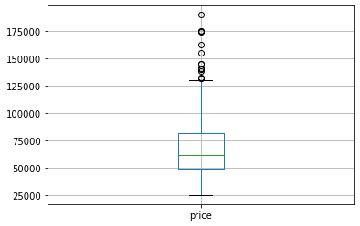

```python
dataset.boxplot(column='price')
```

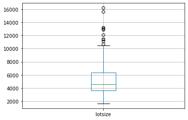

```python
dataset.boxplot(column='lotsize')
```

As predicted by the Standard Deviation values, it’s clear from the above bloxplot that **'price'** and **'lotsize'** has **outliers** which will affect the **mean value** of the attributes.

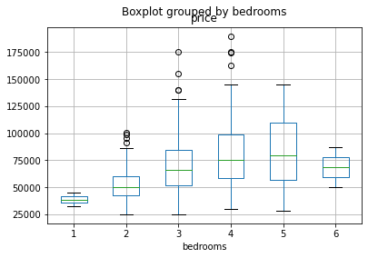

```python
dataset.boxplot(column='price', by='bedrooms')
```

**Average price** of houses **increases** with the **increase in no. of bedrooms** until 5 then reduces as per the avaliable dataset.

```python
dataset['airco'].value_counts()
```

```
no     373
yes    173
Name: airco, dtype: int64
```

**68%** of the houses **donot have Air-conditioning**

```python
dataset['recroom'].value_counts()
```

```
no     449
yes     97
Name: recroom, dtype: int64
```

Only **18%** of the house has **Recreation Room**

```python
dataset['garagepl'].value_counts()
```

```
0    300
1    126
2    108
3     12
Name: garagepl, dtype: int64
```

**55%** of houses has **NO** Garage

```python
dataset.median()
```

```
ID            273.5
price       62000.0
lotsize      4600.0
bedrooms        3.0
bathrms         1.0
stories         2.0
garagepl        0.0
dtype: float64
```

**Median** of **Price** is **62000** and **sq. meters** is **4600**

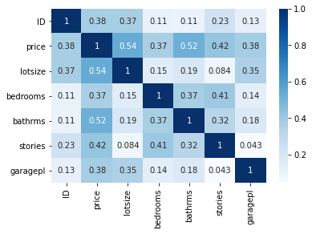

```python
corr = dataset.corr()
sb.heatmap(corr, cmap="Blues", annot=True)
```

**Lot size & Price** has the **highest** Correlation. **Garage places & Stories** has the **least** Correlation.